# Caribou RSF 3.0

Tyler Muhly

28/01/2020

## Introduction

Here I develop a statistical models to quantify the effect of forestry disturbance on caribou distribution. The intent is to use the model to indicate the influence of current and potential future forestry development on caribou use of habitat. Tne model will be implemented as a module (i.e., rsfCLUS) in the caribou and land use simulator (CLUS). Mmodels were fit for the four caribou designatable units (DUs) in British Columbia (BC), (DU6, boreal; DU7, northern moutain; DU8, central mountain; DU9, southern moutnain), as defined by the [Committee on the Status of Endangered Wildlife in Canada (COSEWIC)](https://www.registrelep-sararegistry.gc.ca/default.asp?lang=En&n=E6271D78-1&offset=2#_01_4). DUs were modeled independently, as they are intended to represent groups with unique ecologicla characteristics, and potentially different responses to forestry disturbance.

I use a resource selection function (RSF) framework to develop the statistical model ( [Boyce et al. 1999](https://www.sciencedirect.com/science/article/pii/S0169534799015931), Johnson et al. 2006). This framework uses a logit model to calculate the relationship between caribou occurence and habitat ‘resources’ measured using spatial data. Here I am only considering the effect of forestry disturbance ‘resources’, i.e., cutblocks and roads, on caribou occurrence. This approach simplifies and focuses the RSF onto modeling the effect of forestry disturbance on caribou dsitribution, and is not designed to accurately identify other factors that influence cariobu distribution. This model fitting process was completed to identify the statistical relationship between caribou distribution and forestry disturbance that was generalizable across a caribou DU, without considering the effect of other factors that influence caribou distribution. The theoretical basis for this approach is that these disturbance factors have a significant influence on caribou distribution, regardless of other habitat features. Indeed, cutblocks and linear features from forestry have routinely been shown to have a strong influence on caribou distribution (e.g., [Courbin et al. 2009](https://link.springer.com/article/10.1007/s10980-009-9389-x), [DeCesare et al. 2012](https://esajournals.onlinelibrary.wiley.com/doi/abs/10.1890/11-1610.1), [Mumma et al. 2018](https://www.sciencedirect.com/science/article/pii/S0006320718307225)) and survival ( [Wittmer et al. 2007](https://besjournals.onlinelibrary.wiley.com/doi/full/10.1111/j.1365-2656.2007.01220.x), [Johnson et al. 2015](https://www.sciencedirect.com/science/article/pii/S0006320715001160)).

I also fit models with functional reponses by caribou to cutblocks and roads. Individual wildlife, including caribou, likely respond to habitat differently (i.e., avoid or use roads or cutblocks) depending on the availability of that habitat to them (i.e., the degree that their home range is fragmented by roads or cutblocks). Functional response models in RSFs empirically account for this theroetical response by including an interaction term between the habitat feature at a location and the availability of that feature in the surronding environment ( [Matthiopoulos et al. 2011](https://esajournals.onlinelibrary.wiley.com/doi/full/10.1890/10-0751.1)). I hypothesized that cariobu woudl be more likely to avoid cutblocks and roads as the amount of these features increased in cariobu home ranges, as patches of habtiat further form these disturbances would become increwasingly rare, adn thus increasingly improtant for avoiding predation. Thefroe, I tested for fucntional reponses and included them if a fucntional repsonse was evident in the reponse variable (i.e., caribou distrbution).

The caribou-forestry disturbance model (CFDM) created here can be used as a spatial indicator of current and simulated future effects of forestry activity on caribou habitat quality. For example, the sum of CFDM outputs can be calculated within caribou herd ranges or critical habitat types, and changes in the sum value can be used to indicate changes in forstry disturbance influencing caribou habitat quality over time.

## Methods

I sampled locations ‘available’ to caribou, i.e., the 0’s in the binomial distribution of the dependent variable, by calculating the seasonal home ranges of individual animals and randomly sampling locations within these areas. I calculated home ranges using the kernelUD function in the adehabitatHR ( [Calenge et al. 2011](https://cran.r-project.org/web/packages/adehabitatHR/vignettes/adehabitatHR.pdf)) package of Program R. I varied the smoothing parameter (*h*) in the bivariate normal kernel algorithm and visually assesed the fit of 95% kernel polygons to the telemetry data. I selected the polygons with an *h* value that appeared to best fit the data ( [Hemson et al. 2005](https://besjournals.onlinelibrary.wiley.com/doi/full/10.1111/j.1365-2656.2005.00944.x), [Calenge et al. 2011](https://cran.r-project.org/web/packages/adehabitatHR/vignettes/adehabitatHR.pdf)), i.e., that reasonably formed contiguous habitat areas (i.e., connected patches) without including large extents greater than 1km from telemetry locations. Animals with less than 50 locations in a season were removed from the analysis, as this is considered the minimum number of locations needed to calculate a home range ( [Seaman et al. 1999](https://www.jstor.org/stable/3802664?seq=1), [Kernohan et al. 2001](https://www.sciencedirect.com/science/article/pii/B9780124977815500062)). Seasons were defined as: summer (15-May to 31-Oct), early winter (01-Nov to 15-Jan) and late winter (16-Jan to 14-May), based on a review of the literature on variation in the seasonal distribution of caribou in British Columbia. Within each seasonal home range, I randomly sampled 1,000 locations.

I estimated the distance of ‘used’ and ‘available’ locations to the nearest resource road and cutblock. Cutblock locations were estimated using the [consolidated cutblocks](https://catalogue.data.gov.bc.ca/dataset/harvested-areas-of-bc-consolidated-cutblocks-) data compiled by the BC government. Road locations were estimated using data compiled to support the [British Columbia Cumulative Effects Framework](https://www2.gov.bc.ca/gov/content/environment/natural-resource-stewardship/cumulative-effects-framework). This data is not as easily accessible to the public, but is not private or proprietary, and thus can be requested from the cumulative effects program. The data classifies roads into various types. Our focus was on roads developed for resource extraction (particularly forestry), thus, we classified all unpaved road types as ‘resource roads’. Cutblock and roads data were rasterized at a 1ha resolution, and the Euclidean distance of each raster with a cutblock or resource road was calculated in ArcGIS at 1 ha resolution and attributed to corresponding ‘used’ and ‘available’ caribou locations.

I fit GLMMs with distance to cutblock and distance to road covariates as fixed effects and random effects at the individual animal level. These random effects accounted for individual variation in response to cutblocks and roads in the model, so that the fixed effects can be considered as ‘population‐level’ effects (i.e.,the effect on an ‘average’ animal) of cutblocks and roads on caribou distribution ( [Gillies et al. 2006](https://besjournals.onlinelibrary.wiley.com/doi/full/10.1111/j.1365-2656.2006.01106.x)). I examined the data for variability in the response to cutblocks and roads at the herd-level, assuming animals from the same herd had similar reponses, and also fit GLMMs with random effects for cutblocks and roads at the herd level.

I fit models with and without functional responses to roads and cutblocks and visualy assessed whether a functional response was evident, i.e., caribou use of cutblocks and roads varied as the average distance to cutblocks and roads changed within their home ranges. I calculated the availability of cutblocks and roads to an individual animal as the average distance to cutblocks and roads at ‘available’ locations sampled in the home range of that animal (see [Matthiopoulos et al. 2011](https://esajournals.onlinelibrary.wiley.com/doi/full/10.1890/10-0751.1)).

Clearly, other habitat characteristics besides forestry disturbance influence caribou distribution (e.g., terrain and vegetation, as they relate to food and predation risk; see for example, [Terry et al. 2000](https://besjournals.onlinelibrary.wiley.com/doi/full/10.1046/j.1365-2664.2000.00523.x), [Apps et al. 2001](http://www.env.gov.bc.ca/cariboo/env_stewardship/wildlife/inventory/caribou/northcar/hmi/hsi06-01.pdf), [Johnson et al. 2004](https://besjournals.onlinelibrary.wiley.com/doi/10.1111/j.0021-8901.2004.00899.x), [Apps & McLellan 2006](https://www.sciencedirect.com/science/article/pii/S000632070500546X)), and I initially attempted to fit models with some of these other factors. However, this led to the development of complex habitat models that did not improve my ability to estimate the effects of disturbance on caribou distribution. Instead, model building and interpretation became bogged down due to the difficulty in fitting a generalizable habitat model to unique habitats acorss a given DU. However, I did evaluate correlation between the forestry disturbance factors modeled here and other habtiat features (e.g., elevation, slope, forest stand characteristics) to ensure they were not completely confounded. Specifically, I tested for correlations using a Spearman correlation, ensuring correlation coefficients between covariates were less than 0.7, and by evalauting variance inflation factors (VIFs) in simple generalized linear models (GLMs), and ensuring VIFs were less than 10 ( [DeCesare et al. 2012](https://esajournals.onlinelibrary.wiley.com/doi/abs/10.1890/11-1610.1)). This provided reassurance that distance to cublocks or roads was not completely confounded with some other habitat feature driving caribou distribution.

## Results

### DU6

Caribou location data in DU6 was collected from 160 animals from the Calendar, Chinchaga, Maxhamish, Westside Fort Nelson (formerly Parker and Prophet ranges), and Snake-Sahtaneh herds. The number of animals sampled in each herd ranged from 5 to 43 and the number of telemetry locations ranged from 8,144 to 57,307 per herd (Table 1).

**Table 1. Number of Animals and Telemetry Locations Sampled by Caribou Herd in DU6 (Boreal).**

| Herd | Animals | Locations |
| --- | --- | --- |
| Calendar | 33 | 40937 |
| Chinchaga | 43 | 53993 |
| Maxhamish | 33 | 40295 |
| Parker | 7 | 8240 |
| Prophet | 5 | 8144 |
| Snake-Sahtaneh | 39 | 57307 |

#### Herd-Level Effect of Forestry on Caribou Distribution

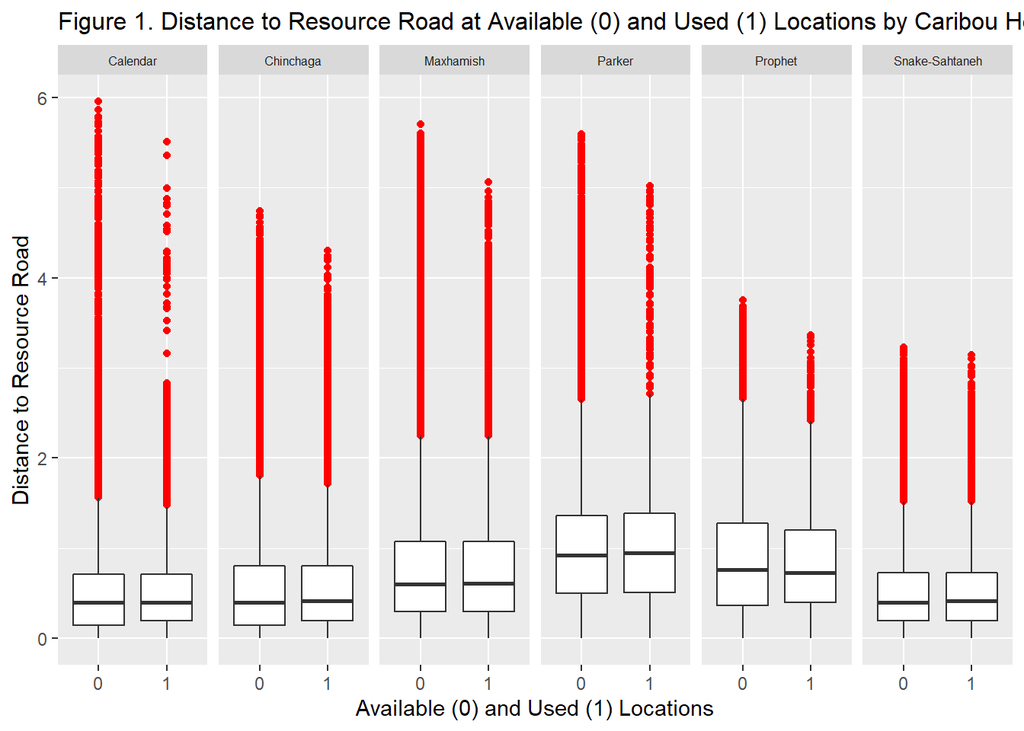

There was variability in caribou response to cutblocks across herds in DU6 (Fig. 2). For example, caribou in the Calendar adn Maxhamish herds used areas closer to cutblocks compared to other herds. A random effect for distance to cutblock was included in the GLMM to account for this variability.

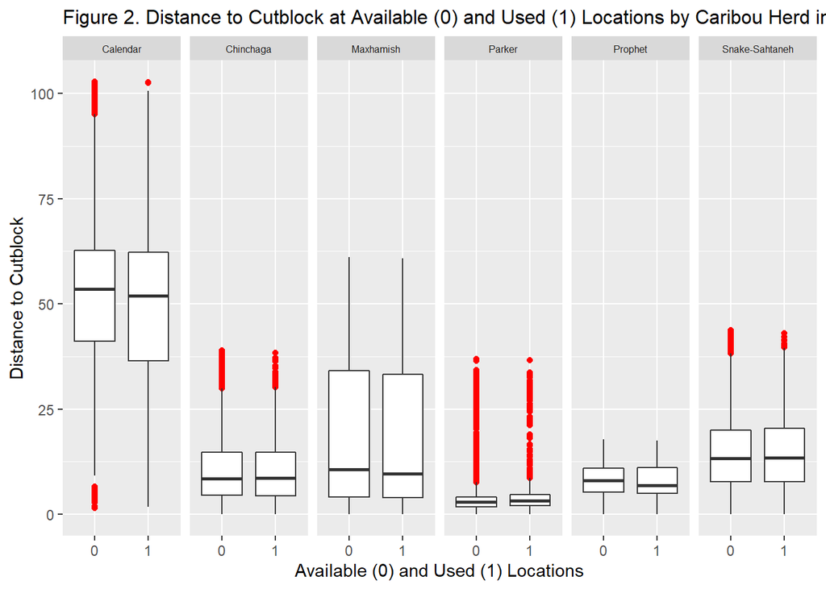

#### Caribou-Forestry Disturbance Model

I fit a model with a functional response for distance to road but not cutblock (Table 4). The model indicated a weak (non-significant), negative effect of cutblocks on caribou distribution. Visual assessment of model predictions indicated no clear change in caribou use of habitat near cutblocks as the average distance to cublock in their home ranges changed. However, there was clearly greater avoidance of roads by caribou as the distance to roads sampled within home ranges decreased (see 3d plots plot below).

```r
# model spec
model.lme4.du6.cut.rd.fxn <- glmer (pttype ~ dist_cut_min_all +
                                                distance_to_resource_road +
                                                dist_rd_E +
                                                distance_to_resource_road*dist_rd_E +
                                      (dist_cut_min_all + distance_to_resource_road || HERD_NAME) +
                                      (dist_cut_min_all + distance_to_resource_road || animal_id),
                                      data = rsf.data.du6,
                                      family = binomial (link = "logit"),
                                      verbose = T)
# check residuals
binnedplot (fitted (model.lme4.du6.cut.rd.fxn),
             residuals(model.lme4.du6.cut.rd.fxn, type = "response"),
             nclass = NULL,
             xlab = "Expected Values",
             ylab = "Average residual",
             main = "DU6 Model Binned Residual Plot",
             cex.pts = 0.4,
             col.pts = 1,
             col.int = "red")
```

**Table 4. Fixed Effect Coefficients of the DU6 Caribou-Forestry Disturbance Model.**

| Coefficient | Coefficient.Estimate | Std..Error | z.value | p.value |
| --- | --- | --- | --- | --- |
| Intercept | -1.451 | 0.170 | -8.517 | 0.000 |
| Distance to Cutblock | 0.009 | 0.009 | 1.008 | 0.313 |
| Distance to Resource Road | 0.343 | 0.067 | 5.116 | 0.000 |
| Average Distance to Resource Road (Home Range) | -0.331 | 0.198 | -1.670 | 0.095 |
| Distance to Resource Road x Average Distance to Resource Road | -0.262 | 0.090 | -2.899 | 0.004 |

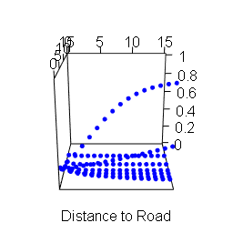

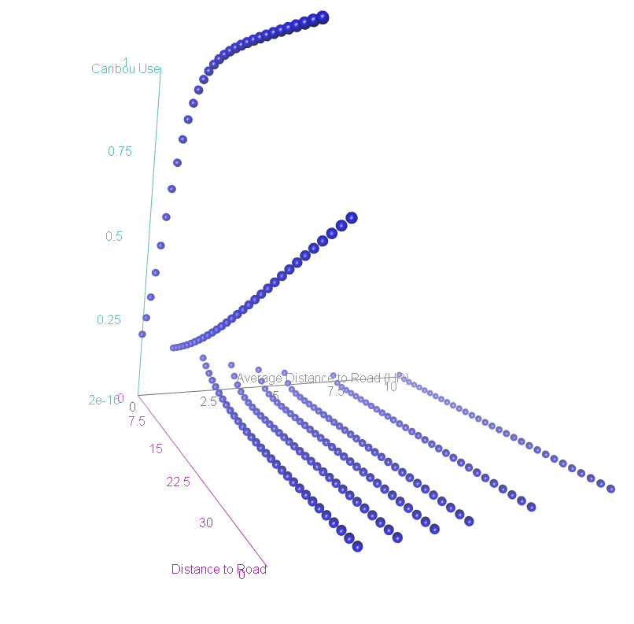

DU6 Caribou Fucntional Response to Road

```r
data.road.test <- read.csv (here ("R/caribou_habitat/data", "rd_fxn_test_data.csv"))

plot3d(x = data.road.test$distance_to_resource_road,
       y = data.road.test$dist_res_road_E,
       z = data.road.test$predict_du6,
       xlab = "Distance to Road",
       zlab = "Caribou Use" ,
       ylab = "Average Distance to Road (HR)",
       xlim = c (0, 15),
       ylim = c(0, 15),
       zlim = c (0, 1),
       col = "blue", type = "p", size = 5, box = F)

play3d( spin3d( axis = c(0, 0, 1), rpm = 6), duration = )

movie3d (spin3d (axis = c(0, 0, 1),
                 rpm = 6),
         movie = "du6_fxn",
         dir = "C:\\Work\\caribou\\clus_github\\R\\caribou_habitat\\images\\",
         type = "gif",
         duration = 5,
         startTime = 0)
```

Random effects in the DU6 model indicated that caribou response to roads was relatively consistent across herds (Table 5). However, there was much more variability in the caribou response to cutblocks. Cariobu in the Calendar, Chinchaga and Prophet herds showed weak use of habtiat near cutblocks, whereas caribou in teh Maxhamish, Parker and Snake-Sahtaneh showed avoidance of cutblocks.

**Table 5. Random Effect Herd-Level Coefficients of the DU6 Caribou-Forestry Disturbance Model.**

| Herd | Intercept | Distance.to.Cutblock | Distance.to.Road |
| --- | --- | --- | --- |
| Calendar | -1.111 | -0.005 | 0.354 |
| Chinchaga | -1.613 | -0.002 | 0.375 |
| Maxhamish | -1.526 | 0.016 | 0.335 |
| Parker | -1.517 | 0.036 | 0.346 |
| Prophet | -1.283 | -0.001 | 0.335 |
| Snake-Sahtaneh | -1.654 | 0.009 | 0.316 |

### DU7

Caribou location data in DU7 was collected from 131 animals from the Charlotte Alplands, Chase, Finlay, Frog, Graham, Itch-Ilgachuz, Muskwa, Pink Mountain, Rainbows, Spatsizi, Telkwa, Tsenaglode and Tweedsmuir herds. The number of animals sampled ranged from 1 to 35 per herd and the number of telemetry locations ranged from 856 to 41,837 per herd (Table 6).

**Table 6. Number of Animals and Telemetry Locations Sampled by Caribou Herd in DU7.**

| Herd | Animals | Locations |
| --- | --- | --- |
| Charlotte Alplands | 4 | 3908 |
| Chase | 4 | 5827 |
| Finlay | 1 | 3020 |
| Frog | 4 | 8783 |
| Graham | 17 | 20473 |
| Itcha-Ilgachuz | 21 | 41837 |
| Muskwa | 19 | 10123 |
| Pink Mountain | 8 | 2599 |
| Rainbows | 9 | 8249 |
| Spatsizi | 5 | 12232 |
| Telkwa | 1 | 856 |
| Tsenaglode | 3 | 1381 |
| Tweedsmuir | 35 | 32131 |

#### Herd-Level Effect of Forestry on Caribou Distribution

There was variability in caribou response to resource roads across caribou herds in DU7 (Fig. 3). For example, caribou in the Chase, Graham, Itcha-Ilgachuz, Tsenaglode and Tweedsmuir tended to be further from roads, whereas caribou in the Frog tended ot be closer to roads. A random effect for distance to road was included in the GLMM to account for this variability.

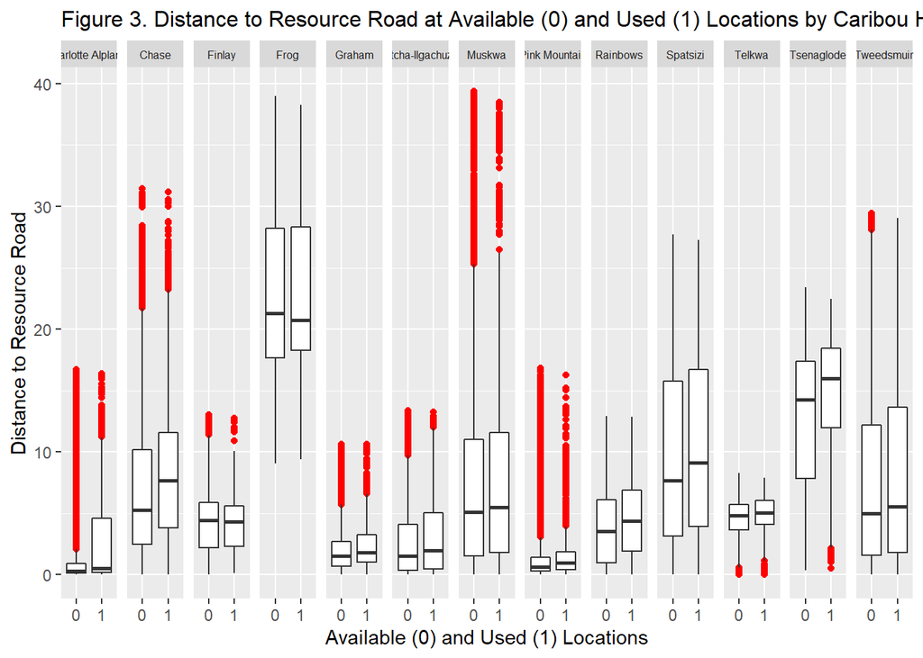

There was variability in caribou response to cutblocks across herds in DU7 (Fig. 4). For example, caribou in the Itcha-Ilgachuz, Muskwa, Pink Mountain and Rainbows herds used areas further from cutblocks, whereas cariou in the Frog and Tsenaglode herds used areas closer to cutblocks. A random effect for distance to cutblock was included in the GLMM to account for this variability.

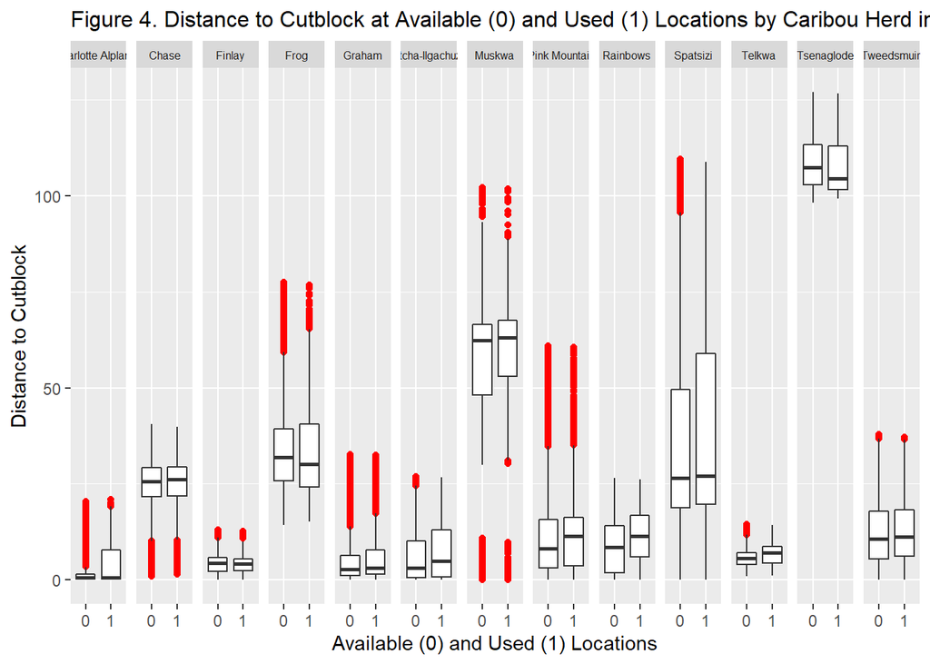

#### Caribou-Forestry Disturbance Model

```r
# model spec
model.lme4.du7.cut.rd.fxn <- glmer (pttype ~ dist_cut_min_all +
                                             distance_to_resource_road +
                                             dist_rd_E +
                                             distance_to_resource_road*dist_rd_E +
                                        (dist_cut_min_all + distance_to_resource_road || animal_id) +                                         (dist_cut_min_all + distance_to_resource_road || HERD_NAME),
                                  data = rsf.data.du7,
                                  family = binomial (link = "logit"),
                                  verbose = T)
# check residuals
binnedplot (fitted (model.lme4.du7.cut.rd.fxn),
             residuals(model.lme4.du7.cut.rd.fxn, type = "response"),
             nclass = NULL,
             xlab = "Expected Values",
             ylab = "Average residual",
             main = "DU7 Model Binned Residual Plot",
             cex.pts = 0.4,
             col.pts = 1,
             col.int = "red")
```

**Table 5. Fixed Effect Coefficients of the DU7 Caribou-Forestry Disturbance Model.**

| Coefficient | Coefficient.Estimate | Std..Error | z.value | p.value |
| --- | --- | --- | --- | --- |
| Intercept | -1.373 | 0.218 | -6.293 | 0.000 |
| Distance to Cutblock | 0.003 | 0.010 | 0.329 | 0.742 |
| Distance to Resource Road | 0.081 | 0.025 | 3.220 | 0.001 |
| Average Distance to Resource Road (Home Range) | -0.016 | 0.020 | -0.813 | 0.416 |
| Distance to Resource Road x Average Distance to Resource Road | -0.003 | 0.002 | -1.440 | 0.150 |

Random effects in the DU7 model indicated that caribou avodied roads consistently across herds, although there was significant variability in the strength of avoidance (Table 6). There was more variability in the caribou response to cutblocks. Cariobu in the Charlotte Alplands, Finlay, Frog, Graham, Pink Mountain, Spatsizi, Tsenaglode and TWeedsmuir tended to be closer to cutblocks, whereas caribou in other herds tended to avoid cutblocks.

**Table 6. Random Effect Herd-Level Coefficients of the DU7 Caribou-Forestry Disturbance Model.**

| Herd | Intercept | Distance.to.Cutblock | Distance.to.Road |
| --- | --- | --- | --- |
| Charlotte Alplands | -0.758 | -0.040 | 0.207 |
| Chase | -1.305 | 0.003 | 0.075 |
| Finlay | -0.934 | -0.015 | 0.051 |
| Frog | -0.673 | -0.008 | 0.085 |
| Graham | -1.801 | -0.011 | 0.147 |
| Itcha-Ilgachuz | -1.041 | 0.002 | 0.018 |
| Muskwa | -2.806 | 0.017 | 0.042 |
| Pink Mountain | -2.174 | -0.009 | 0.147 |
| Rainbows | -0.656 | 0.064 | 0.024 |
| Spatsizi | -1.379 | -0.002 | 0.057 |
| Telkwa | -1.751 | 0.043 | 0.097 |
| Tsenaglode | -0.927 | -0.001 | 0.083 |
| Tweedsmuir | -1.632 | -0.002 | 0.027 |

### DU8

**Table 7. Number of Animals and Telemetry Locations Sampled by Caribou Herd in DU8.**

| Herd | Animals | Locations |
| --- | --- | --- |
| Burnt Pine | 16 | 5414 |
| Kennedy Siding | 38 | 31502 |
| Moberly | 14 | 13946 |
| Narraway | 19 | 11558 |
| Quintette | 57 | 65431 |
| Scott | 8 | 10164 |

#### Herd-Level Effect of Forestry on Caribou Distribution

There was variability in caribou response to resource roads across caribou herds in DU8 (Fig. 5). For example, caribou in the Burnt Pine, Kennedy Siding and Scott herds tended to be closer to roads, whereas caribou in the Moberly, Narraway and Quintette tended to be further from roads. A random effect for distance to road was included in the GLMM to account for this variability.

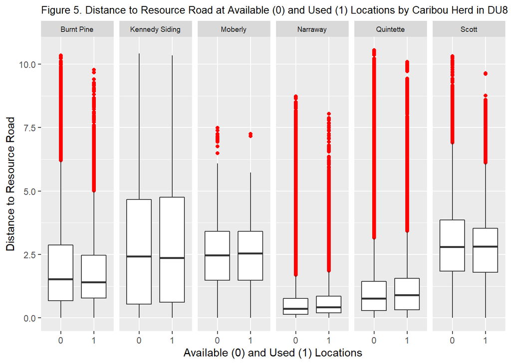

There was variability in caribou response to cutblocks across herds in DU8 (Fig. 6). For example, caribou in the Quintette herd tended to use areas further from cutblocks, whereas caribou in the Narraway herd tended to be closer to cutblocks. A random effect for distance to cutblock was included in the GLMM to account for this variability.

[figure not shown]

#### Caribou-Forestry Disturbance Model

```r
# model spec
model.lme4.du8.cut.rd.fxn <- glmer (pttype ~ dist_cut_min_all +
                                            distance_to_resource_road +
                                            dist_rd_E +
                                            distance_to_resource_road*dist_rd_E +
                                  (dist_cut_min_all + distance_to_resource_road || HERD_NAME) +
                                  (dist_cut_min_all + distance_to_resource_road || animal_id),
                                  data = rsf.data.du8,
                                  family = binomial (link = "logit"),
                                  verbose = T)
# check residuals
binnedplot (fitted (model.lme4.du8.cut.rd.fxn),
             residuals(model.lme4.du8.cut.rd.fxn, type = "response"),
             nclass = NULL,
             xlab = "Expected Values",
             ylab = "Average residual",
             main = "DU8 Model Binned Residual Plot",
             cex.pts = 0.4,
             col.pts = 1,
             col.int = "red")
```

**Table 8. Fixed Effect Coefficients of the DU8 Caribou-Forestry Disturbance Model.**

| Coefficient | Coefficient.Estimate | Std..Error | z.value | p.value |
| --- | --- | --- | --- | --- |
| Intercept | -1.694 | 0.152 | -11.116 | 0.000 |
| Distance to Cutblock | -0.079 | 0.031 | -2.559 | 0.010 |
| Distance to Resource Road | 0.239 | 0.067 | 3.580 | 0.000 |
| Average Distance to Resource Road (Home Range) | -0.018 | 0.063 | -0.281 | 0.778 |
| Distance to Resource Road x Average Distance to Resource Road | -0.056 | 0.026 | -2.174 | 0.030 |

Random effects in the DU8 model indicated that caribou avoided roads consistently across herds, although there was variability in the strength of avoidance (Table 9). There was also generally consistent use of areas close to cutblocks acorss herds, with the exception of the Quintette herd, where caribou avoided cutblocks.

**Table 9. Random Effect Herd-Level Coefficients of the DU8 Caribou-Forestry Disturbance Model.**

| Herd | Intercept | Distance.to.Cutblock | Distance.to.Road |
| --- | --- | --- | --- |
| Burnt Pine | -1.807 | -0.036 | 0.132 |
| Kennedy Siding | -1.720 | -0.170 | 0.351 |
| Moberly | -1.810 | -0.148 | 0.304 |
| Narraway | -1.819 | -0.066 | 0.291 |
| Quintette | -1.758 | 0.012 | 0.193 |
| Scott | -1.244 | -0.063 | 0.163 |

### DU9

Caribou location data in DU9 was collected from 25 animals from the Hart Ranges, Nakusp and South Selkirks herds. The number of animals sampled per herd ranged from 6 to 11 and the number of telemetry locations per herd ranged from 1,821 to 4,917 per herd (Table 10).

**Table 10. Number of Animals and Telemetry Locations Sampled by Caribou Herd in DU9.**

| Herd | Animals | Locations |
| --- | --- | --- |
| Hart Ranges | 11 | 4917 |
| Nakusp | 8 | 1821 |
| South Selkirks | 6 | 2629 |

#### Herd-Level Effect of Forestry on Caribou Distribution

There was variability in caribou response to resource roads across caribou herds in DU9 (Fig. 7). For example, caribou in the Hart Ranges tended to be closer to roads, whereas caribou in the Nakusp and South Slekirks tended to be further from roads. A random effect for distance to road was included in the GLMM to account for this variability.

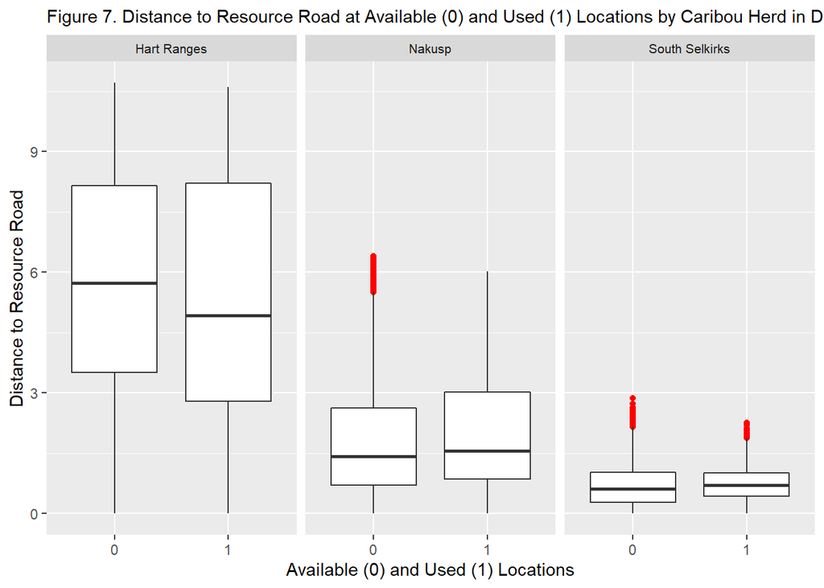

There was variability in caribou response to cutblocks across herds in DU9 (Fig. 8). For example, caribou in the Hart Ranges herd tended to use areas closer to cutblocks, whereas caribou in the Nakusp herd tended to be further from cutblocks. A random effect for distance to cutblock was included in the GLMM to account for this variability.

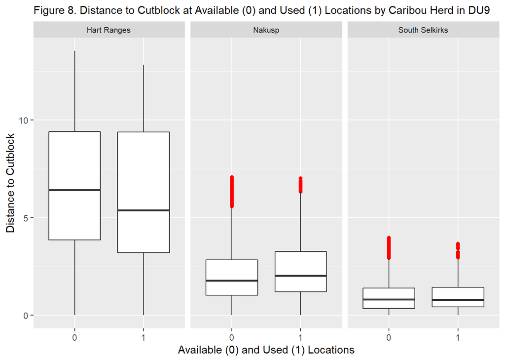

#### Caribou-Forestry Disturbance Model

```r
# model spec
model.lme4.du9.cut.rd.fxn <- glmer (pttype ~ dist_cut_min_all +
                                                distance_to_resource_road +
                                                dist_rd_E +
                                                distance_to_resource_road*dist_rd_E +
                                      (dist_cut_min_all + distance_to_resource_road || HERD_NAME) +
                                      (dist_cut_min_all + distance_to_resource_road || animal_id),
                                      data = rsf.data.du9,
                                      family = binomial (link = "logit"),
                                      verbose = T)
# check residuals
binnedplot (fitted (model.lme4.du9.cut.rd.fxn),
             residuals(model.lme4.du9.cut.rd.fxn, type = "response"),
             nclass = NULL,
             xlab = "Expected Values",
             ylab = "Average residual",
             main = "DU9 Model Binned Residual Plot",
             cex.pts = 0.4,
             col.pts = 1,
             col.int = "red")
```

**Table 11. Fixed Effect Coefficients of the DU9 Caribou-Forestry Disturbance Model.**

| Coefficient | Coefficient.Estimate | Std..Error | z.value | p.value |
| --- | --- | --- | --- | --- |
| Intercept | -1.979 | 0.499 | -3.964 | 0.000 |
| Distance to Cutblock | 0.043 | 0.070 | 0.617 | 0.537 |
| Distance to Resource Road | 0.118 | 0.088 | 1.341 | 0.180 |
| Average Distance to Resource Road (Home Range) | -0.165 | 0.093 | -1.787 | 0.074 |
| Distance to Resource Road x Average Distance to Resource Road | -0.006 | 0.016 | -0.375 | 0.708 |

Random effects in the DU9 model indicated that caribou avoided roads consistently across herds, although there was variability in the strength of avoidance (Table 12). There was variability in use of areas close to cutblocks acorss herds, where caribou in teh Nakuysp herd tended to strongly avoid cutblocks, whereas cariobu in the other herds did not.

**Table 12. Random Effect Herd-Level Coefficients of the DU9 Caribou-Forestry Disturbance Model.**

| Herd | Intercept | Distance.to.Cutblock | Distance.to.Road |
| --- | --- | --- | --- |
| Hart Ranges | -0.963 | -0.024 | 0.083 |
| Nakusp | -2.424 | 0.168 | 0.007 |
| South Selkirks | -2.539 | -0.011 | 0.262 |

### Conclusions

Research has repeatedly shown that caribou are negatively influenced by forestry activity. This can include neagtive density effects, for example, on caribou survival ( [Wittmer et al. 2007](https://besjournals.onlinelibrary.wiley.com/doi/full/10.1111/j.1365-2656.2007.01220.x), [Johnson et al. 2015](https://www.sciencedirect.com/science/article/pii/S0006320715001160)), and behavioural effects, on caribou distribution (e.g., [Courbin et al. 2009](https://link.springer.com/article/10.1007/s10980-009-9389-x), [DeCesare et al. 2012](https://esajournals.onlinelibrary.wiley.com/doi/abs/10.1890/11-1610.1), [Mumma et al. 2018](https://www.sciencedirect.com/science/article/pii/S0006320718307225)). Here we built on this evidence and developed a CFDM that related forestry disturbance to caribou distribution. The model and the RSF framework used to develop the model is a useful approach for developing an indicator of how forestry influences caribou habitat. This indicator can be linked to forestry simulator models as an indicator of how simulated forstry activity may influence cariobu habtait over space and time. Indeed, we will use this model as an indcaotr of cariobu habtiat quality (spefici to forestry only) in the caribou and land use simualtor (CLUS).

Our CFDM consistently showed a negative effect of roads on cariobu distribtuion. Here we focussed on the efefcts of resource roads (i.e., unpoaved roads) on cariobu, with the intent of representing the effect of roads built to harvest forest stands on caribou. Roads are likely representative of many ecological efefcts of resrource development on cariobu. Roads can act as semi-permeable barriers to caribou, resulting in loss of fucntional habtiat due to cariobu avoidance of areas near roads ( [Dyer et al. 2001](https://www.jstor.org/stable/3803106), [Dyer et al. 2002](https://www.nrcresearchpress.com/doi/abs/10.1139/z02-060#.XkXNFTFKikw), [Wilson et al. 2016](https://www.sciencedirect.com/science/article/pii/S0006320715302147)). Cariobu may also behave differntly near roads, decraseign their time spent resting and icnreasein their time spent moving ( [Murphy and Curato 1987](https://www.nrcresearchpress.com/doi/abs/10.1139/z87-375#.XkXOZjFKikx)), potentially neagtively affecting energy intake. Caribou may also avoid roads to minimize predation risk ( [Dussault et al. 2012](https://royalsocietypublishing.org/doi/pdf/10.1098/rspb.2012.1700)), as predators such as wolves and bears may make use of these areas to hunt prey ( [Whittington et al. 2011](https://besjournals.onlinelibrary.wiley.com/doi/full/10.1111/j.1365-2664.2011.02043.x), [Latham et al 2011](https://esajournals.onlinelibrary.wiley.com/doi/abs/10.1890/11-0666.1)). The CFDM does not attempt to disentangle or measure these different processes, but it is assumed that teh neagtive realtionship bewtween cariobu adn roads is indicative of these processes.

Importantly, we identified a functional response between roads and caribou distribution, and included this in our model. Functional responses show how animal use of habtiat vaires as afucntion of the availability of that habitat to them on the ladnscape. Funcaiotnal repsonses can be particualrly improtatn for modelign the eefcts of distruabnes such as fortesty on cariobu, as cariobu avodiance, or use, of disturabnce features likely changes as the ladnscape is increasingly disturbed. We foudn that cariobu were more likely to avoid roads in ladnscapes with more roads. This suggests that unroaded habitat patches become increasingly improtatn to cariobu as the amount or roads in tehir hoem rnages increases. This efefct is imrptoant to consider when simuating the efefcts of forestry distruabnce on cariobu through space and tiem. Lacnsdape context is important, thus teh developemtn of roads in ladnscapes with low road developlemtn shoudl have realtively small efefct on cariobu habtiat use comapred to ladnscapes where a lot of road development has laready occurred.

The efefct of cutblocks on cariobu dsitribtuion was neagtive in DU’s 6, 7 and 9, but positive in DU 8. In addtion, teh effect of cutlbocks on cariobu distribtuion was generally weaker than the efefct on roads, there was greater variability in herd reponses to cutblocks comapred to roads, adn tehre was no cler fucntional repsonse in use of areas near cutblocks, and therefore no fucntional repsonse was incldued in teh model. In general, cutblocks are believed to have a neagtive efefct on cariobu, as they provide more forage for ungualets such as moose, thus supporoting higher densities of ungualets adn their predators, such as wolves, that also predate on cariobu ( [Seip 1992](https://www.nrcresearchpress.com/doi/abs/10.1139/z92-206#.XkXfPTFKikw), [DeCesare et al. 2010](https://zslpublications.onlinelibrary.wiley.com/doi/full/10.1111/j.1469-1795.2009.00328.x), [Serrouya et al. 2017](https://peerj.com/articles/3736/?utm_source=TrendMD&utm_campaign=PeerJ_TrendMD_1&utm_medium=TrendMD)). Hoiwever, tehre may be resons why we detcted a weak negative, adn sometimes positive efefct of cutblcosk on cariobu. First, cariobu may use cutblocks periodically throughout the year to access forage. Caribou will select for deciduous shrub species durign summer foraging ( [Denryter et al. 2017](https://www.nrcresearchpress.com/doi/full/10.1139/cjz-2016-0114#.XkbFSjFKikw)), adn these species tend to increase in cutblocks ( [Strong and Gates 2006](https://www.sciencedirect.com/science/article/pii/S0378112705006456)). Resarch in Quebec found that cariobu selected yuonger cutlbocks, presumably becuase of hteir forage benefit ( [Dussault et al. 2012](https://royalsocietypublishing.org/doi/pdf/10.1098/rspb.2012.1700)). Second, the negative effect of cutblocks may occur at larger scales, outside of teh home range. [DeCesare et al. 2012](https://esajournals.onlinelibrary.wiley.com/doi/abs/10.1890/11-1610.1) foudn that cariobu avodied cutblocks at teh range scale (i.e., cariobu herds occurred in areas with fewer cutblocks), but not within their hoem ranges. This suggests the negative predation effect of cutblocks occurs at larger scales, that cariobu are less likely to establish hoem rnage sin areas with mroe cutblocks, perhaps becausethey are avoidng predation risk or they are unabel to survrive in those areas. Clearly, the efefcts of cutblocks on caribou distribtuion is more nuanced than roads. However, the CFDM appears to be a useful indcaotr of the efefcts of cutblocks on cariobu. In general, the effect of cutblocks on caribou distribution is negative in most DUs, which likely correctly represrntes the overall efefct of cutblocks on cariobu. However, it is weaker than teh efefct orf raods, which represents the poitential positive foragign efefcts of cutblocks that roads do not have. In additon, the model random efefcts can be used to adjust for herd-lvele variation in cariobu use of cutblocks.  
The CFDM provides a framweork and modle for testign teh efefcts of simualted future forestry activities on cariobu. It includes random effects to account for variability in responses to cutblcoks and roads across herds, adn a fucntional response to account for the efefct of the ladnscape-level distruabnce on local use of habitat pacthes. These features provide a great deal of flexibility in estimating the effects of forestry cctitves on cariobu.